# a4-eda

## Assignment 4: EDA

In this assignment I will be conducting exploratory data analysis on the FBI crime data set found here https://ucr.fbi.gov/crime-in-the-u.s

The questions my teasm is researching in this project is how does population affect a cities crime rate?

Some sub questions to this are: does population effect speficic crimes more? How do crimes change as population shanges over the years. Does it effect wether or not the crime is violent or not?

# Data Preperation

In order to do some analysis I had to convert the excel files found in the link above to csv. Because some of the columns were not uniform, I rearranged some of those as well.

# Describing the Data Structure

Below we will go over the basic structure of the data and the variables. You will also see that I have to remove some variables and create some new variables to do analysis on.

```r
library(readr)
library(dplyr)
library(stringr)
library(ggplot2)
library(plotly)
library(tidyr)
library(vioplot)
library(doBy)

# load data
cities <- read.csv('data/data.csv')


# change variables to numerics
cities$population <- as.numeric(as.character(cities$population))
cities$violent_crime <- as.numeric(as.character(cities$violent_crime))
cities$murder_and_non_negligent_man_slaughter <- as.numeric(as.character(cities$murder_and_non_negligent_man_slaughter))
cities$forcible_rape <- as.numeric(as.character(cities$forcible_rape))
cities$robbery <- as.numeric(as.character(cities$robbery))
cities$aggravated_assault <- as.numeric(as.character(cities$aggravated_assault))
cities$property_crime <- as.numeric(as.character(cities$property_crime))
cities$burglary <- as.numeric(as.character(cities$burglary))
cities$larceny_theft <- as.numeric(as.character(cities$larceny_theft))
cities$motor_vehicle_theft <- as.numeric(as.character(cities$motor_vehicle_theft))
cities$arson<- as.numeric(as.character(cities$arson))
cities$crime_index_total <- as.numeric(as.character(cities$crime_index_total))
cities$modified_crime_index_total <- as.numeric(as.character(cities$modified_crime_index_total))

# change NA variables to 0
cities[is.na(cities)] <- 0

# remove cities with zero population - bad data rows
cities <- cities[apply(cities["population"],1,function(z) !any(z==0)),]

# view data set
View(cities)

# determine shape
dim(cities)
```

```
## [1] 34583    16
```

```r
# view column names
colnames(cities)
```

```
##  [1] "year"
##  [2] "state"
##  [3] "city"
##  [4] "population"
##  [5] "violent_crime"
##  [6] "murder_and_non_negligent_man_slaughter"
##  [7] "forcible_rape"
##  [8] "robbery"
##  [9] "aggravated_assault"
## [10] "property_crime"
## [11] "burglary"
## [12] "larceny_theft"
## [13] "motor_vehicle_theft"
## [14] "arson"
## [15] "crime_index_total"
## [16] "modified_crime_index_total"
```

```r
# data types of columns
sapply(cities, class)
```

```
##                                   year
##                              "numeric"
##                                  state
##                               "factor"
##                                   city
##                               "factor"
##                             population
##                              "numeric"
##                          violent_crime
##                              "numeric"
## murder_and_non_negligent_man_slaughter
##                              "numeric"
##                          forcible_rape
##                              "numeric"
##                                robbery
##                              "numeric"
##                     aggravated_assault
##                              "numeric"
##                         property_crime
##                              "numeric"
##                               burglary
##                              "numeric"
##                          larceny_theft
##                              "numeric"
##                    motor_vehicle_theft
##                              "numeric"
##                                  arson
##                              "numeric"
##                      crime_index_total
##                              "numeric"
##             modified_crime_index_total
##                              "numeric"
```

```r
# Summary of each column
summary(cities)
```

```
##       year               state                city
##  Min.   :2000   TEXAS       : 2646   Clinton    :   63
##  1st Qu.:2002   PENNSYLVANIA: 2513   Springfield:   57
##  Median :2003   CALIFORNIA  : 2211   Madison    :   56
##  Mean   :2003   NEW JERSEY  : 2205   Jackson    :   53
##  3rd Qu.:2004   MISSOURI    : 1695   Lexington  :   53
##  Max.   :2005   MICHIGAN    : 1572   Ashland    :   47
##                 (Other)     :21741   (Other)    :34254
##    population       violent_crime
##  Min.   :      18   Min.   :    0.00
##  1st Qu.:    2587   1st Qu.:    0.00
##  Median :    6885   Median :    2.00
##  Mean   :   24408   Mean   :   58.64
##  3rd Qu.:   18368   3rd Qu.:   14.00
##  Max.   :11742103   Max.   :59448.00
##
##  murder_and_non_negligent_man_slaughter forcible_rape
##  Min.   :   0.000                       Min.   :   0.000
##  1st Qu.:   0.000                       1st Qu.:   0.000
##  Median :   0.000                       Median :   1.000
##  Mean   :   1.784                       Mean   :   8.555
##  3rd Qu.:   0.000                       3rd Qu.:   5.000
##  Max.   :3472.000                       Max.   :1689.000
##
##     robbery         aggravated_assault property_crime
##  Min.   :    0.00   Min.   :    0.0    Min.   :     0.0
##  1st Qu.:    0.00   1st Qu.:    2.0    1st Qu.:     0.0
##  Median :    2.00   Median :    9.0    Median :    30.0
##  Mean   :   50.12   Mean   :   88.6    Mean   :   442.1
##  3rd Qu.:   10.00   3rd Qu.:   34.0    3rd Qu.:   179.0
##  Max.   :32562.00   Max.   :40880.0    Max.   :176767.0
##
##     burglary       larceny_theft      motor_vehicle_theft
##  Min.   :    0.0   Min.   :     0.0   Min.   :    0.0
##  1st Qu.:   10.0   1st Qu.:    38.0   1st Qu.:    2.0
##  Median :   32.0   Median :   137.0   Median :   10.0
##  Mean   :  200.1   Mean   :   702.6   Mean   :  134.3
##  3rd Qu.:  109.0   3rd Qu.:   451.0   3rd Qu.:   39.0
##  Max.   :37112.0   Max.   :139664.0   Max.   :35847.0
##
##      arson          crime_index_total  modified_crime_index_total
##  Min.   :    0.00   Min.   :     0.0   Min.   :     0.0
##  1st Qu.:    0.00   1st Qu.:     0.0   1st Qu.:     0.0
##  Median :    0.00   Median :     0.0   Median :     0.0
##  Mean   :   10.09   Mean   :   659.4   Mean   :   604.3
##  3rd Qu.:    3.00   3rd Qu.:   199.0   3rd Qu.:   157.0
##  Max.   :92001.00   Max.   :288368.0   Max.   :193083.0
##
```

```r
# view unique cities
unique(cities$city)
```

```
##    [1] Alexander City       Anniston             Athens
##    [4] Auburn               Bessemer             Birmingham
##    [7] Cullman              Daphne               Dothan
##   [10] Enterprise           Fairhope             Florence
##   [13] Fort Payne           Gardendale           Homewood
##   [16] Hoover               Huntsville           Madison
##   [19] Millbrook            Mobile3              Montgomery
##   [22] Moody                Mountain Brook       Muscle Shoals
##   [25] Northport            Opelika              Ozark
##   [28] Pelham               Phenix City          Prattville
##   [31] Prichard             Saraland             Scottsboro
##   [34] Selma                Sheffield            Sylacauga
##   [37] Troy                 Trussville           Tuscaloosa
##   [40] Tuskegee             Vestavia Hills       Anchorage
##   [43] Fairbanks            Apache Junction      Avondale
```

[output cut: 321 more lines]

```r
# make crimes per person columns
#violent
cities["murders_per_person"] <- with(cities, murder_and_non_negligent_man_slaughter / population)
cities["assault_per_person"] <- with(cities, aggravated_assault / population)
cities["rape_per_person"] <- with(cities, forcible_rape / population)
#non-violent
cities["robbery_per_person"] <- with(cities, robbery / population)
cities["theft_per_person"] <- with(cities, larceny_theft / population)
cities["burglary_per_person"] <- with(cities, burglary / population)

# create some population bins
small.pop <- cities %>% filter(population <= 5000)
med.small.pop <- cities %>% filter(population >= 5001 & population <= 15000)
med.large.pop <- cities %>% filter(population >= 15001 & population <= 75000)
large.pop <- cities %>% filter(population >= 75001)
```

# Univariate analysis

Here we look at the distribution of all the data. You can see in the histograms that the x axis scale is quite large, meaning the maximum values are quite high, but most of the data is at the lower end. This is because most of the data comes from smaller cities while larger cities have relatively high amounts of crimes commited.

There is some data missing from columns like violent crime and property crime because earlier year data sets did not include them.

```r
summaryBy(murder_and_non_negligent_man_slaughter + aggravated_assault + forcible_rape + robbery + larceny_theft + burglary ~ year,  data = cities,
          FUN = list(mean, max, min, median, sd))
```

```
##   year murder_and_non_negligent_man_slaughter.mean aggravated_assault.mean
## 1 2000                                  3.96452328              218.248337
## 2 2001                                  5.18118081              217.516974
## 3 2002                                  1.53207693               81.276107
## 4 2003                                  1.53664332               75.312156
## 5 2004                                  0.08469737                8.536924
## 6 2005                                  1.51015912               74.353856
##   forcible_rape.mean robbery.mean larceny_theft.mean burglary.mean
## 1         19.5066519   123.217295         1621.53215     452.12823
## 2         19.7343173   126.703690         1659.45461     468.08856
## 3          7.9504324    45.521363          651.31212     183.46147
## 4          7.6340670    43.240870          627.72374     178.74200
## 5          0.9788732     1.723829           87.96155      23.03692
## 6          7.5646267    42.721909          597.92448     178.07479
##   murder_and_non_negligent_man_slaughter.max aggravated_assault.max
```

[output cut: 55 more lines]

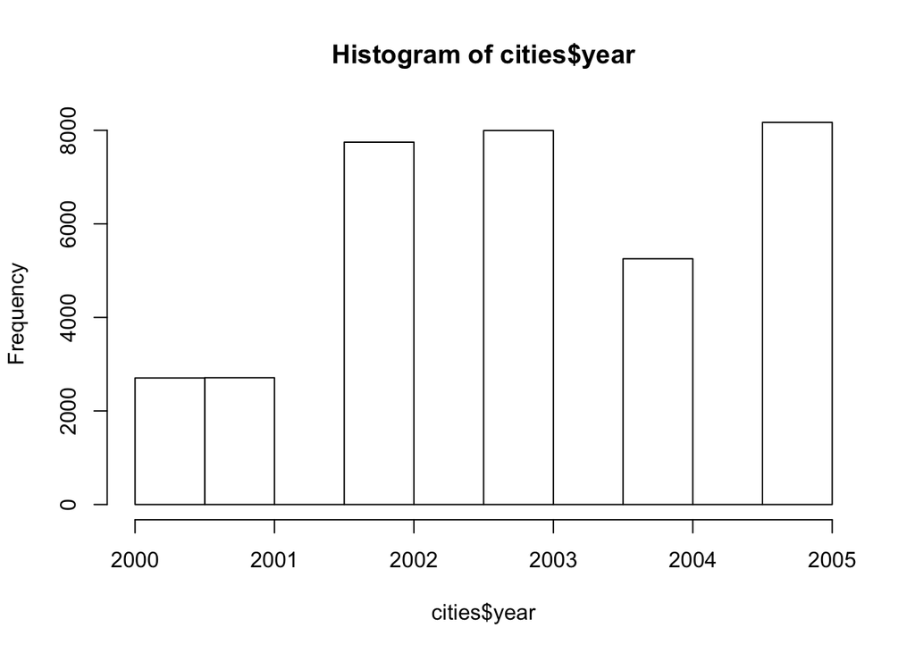

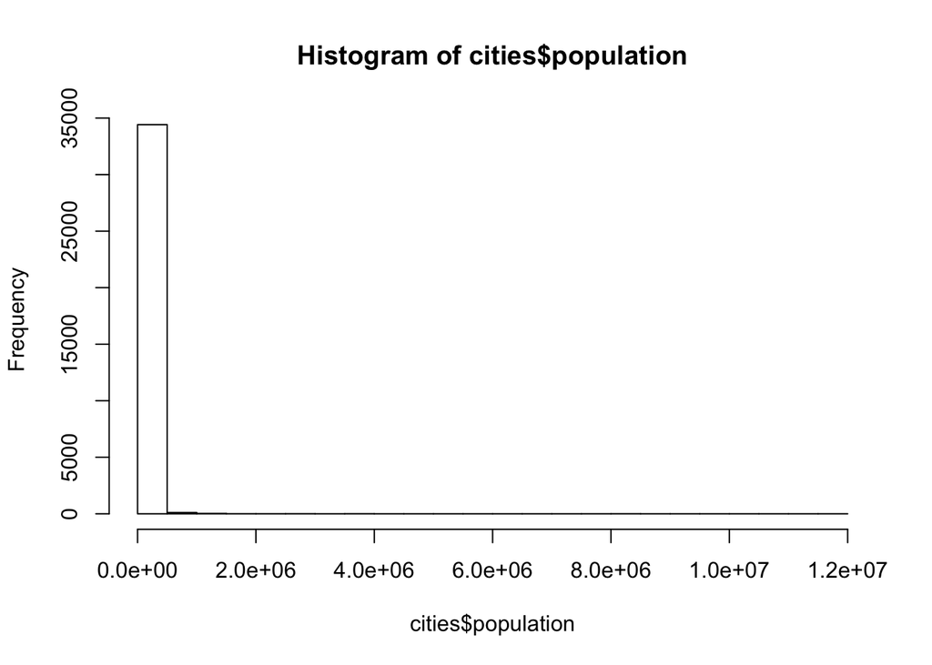

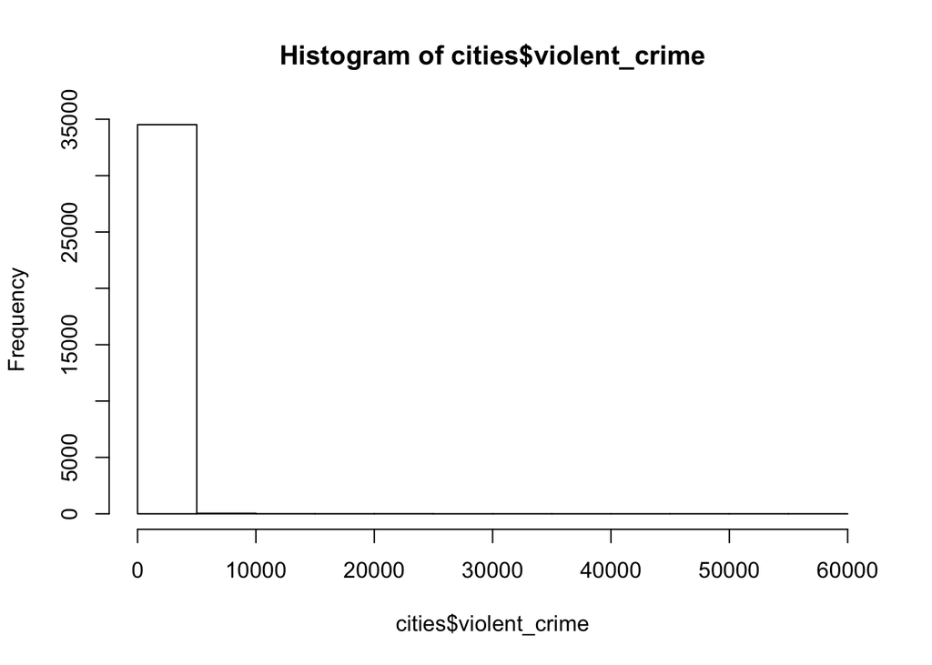

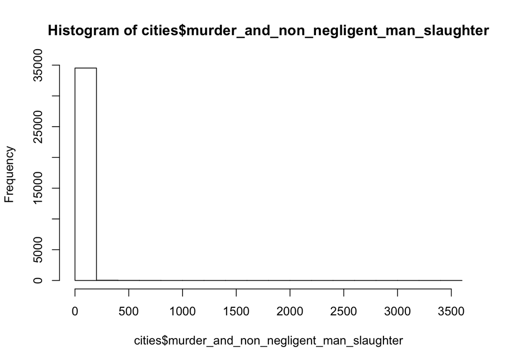

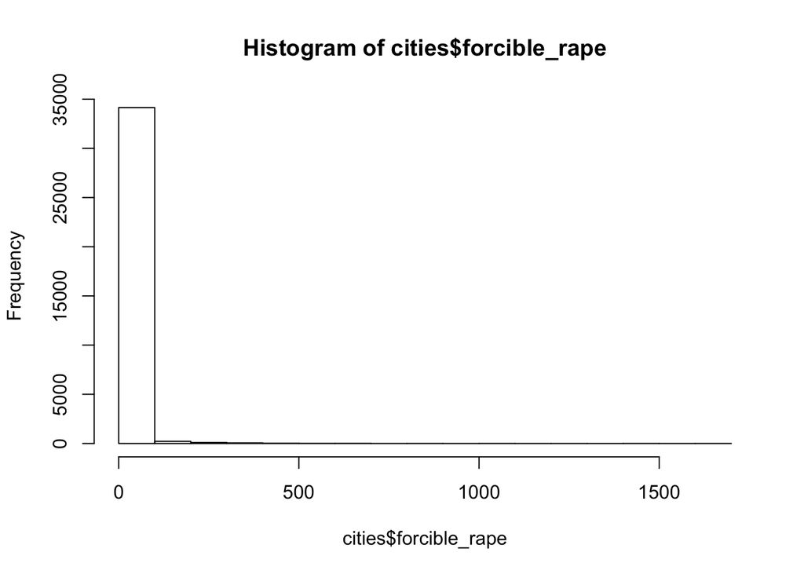

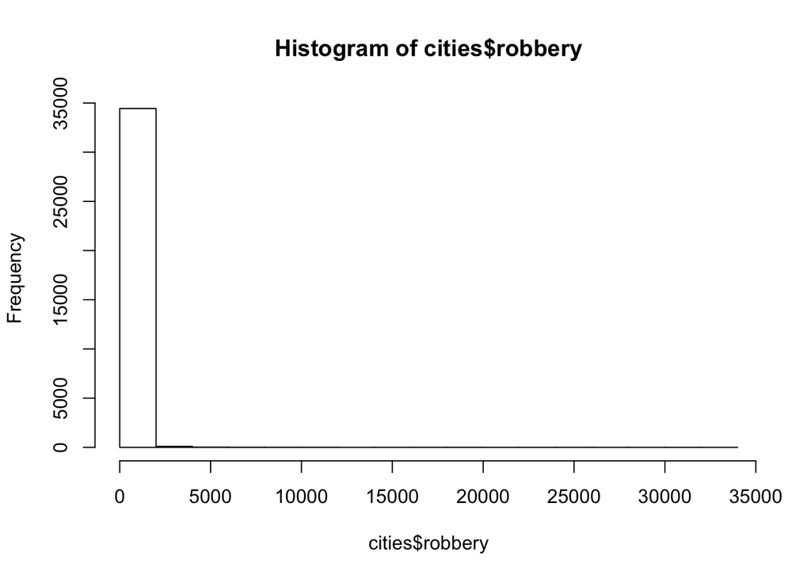

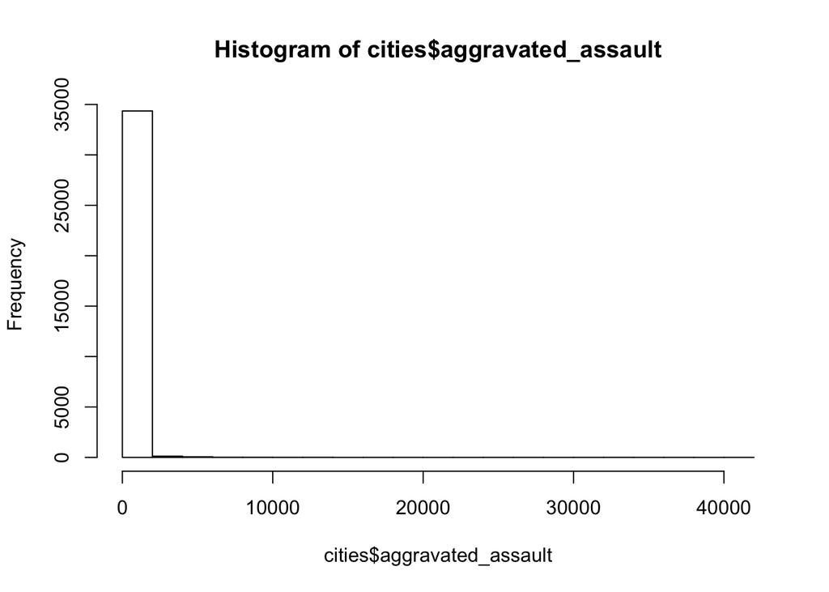

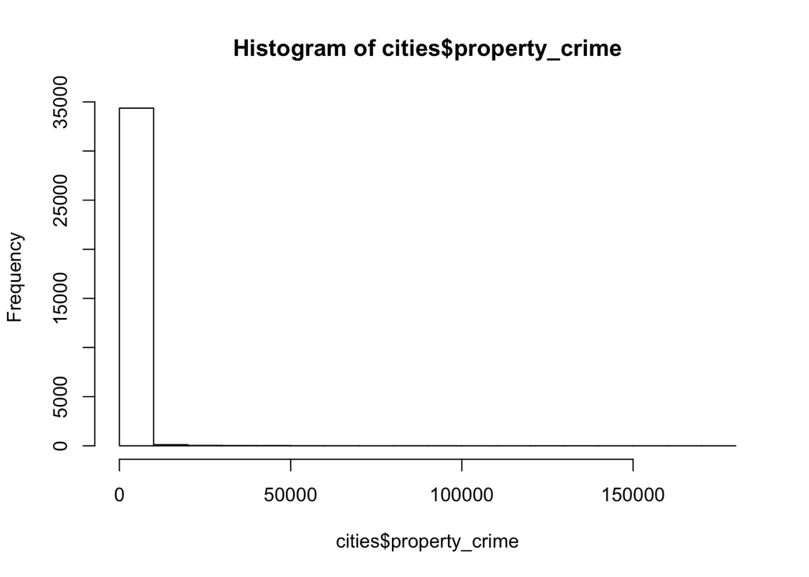

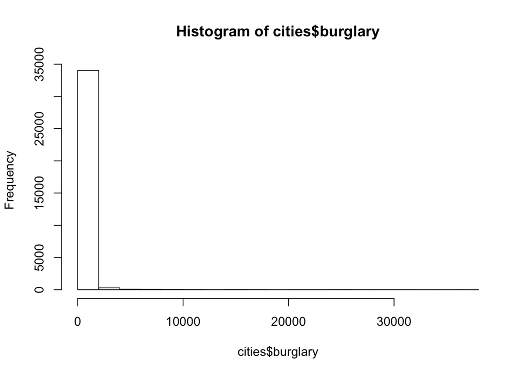

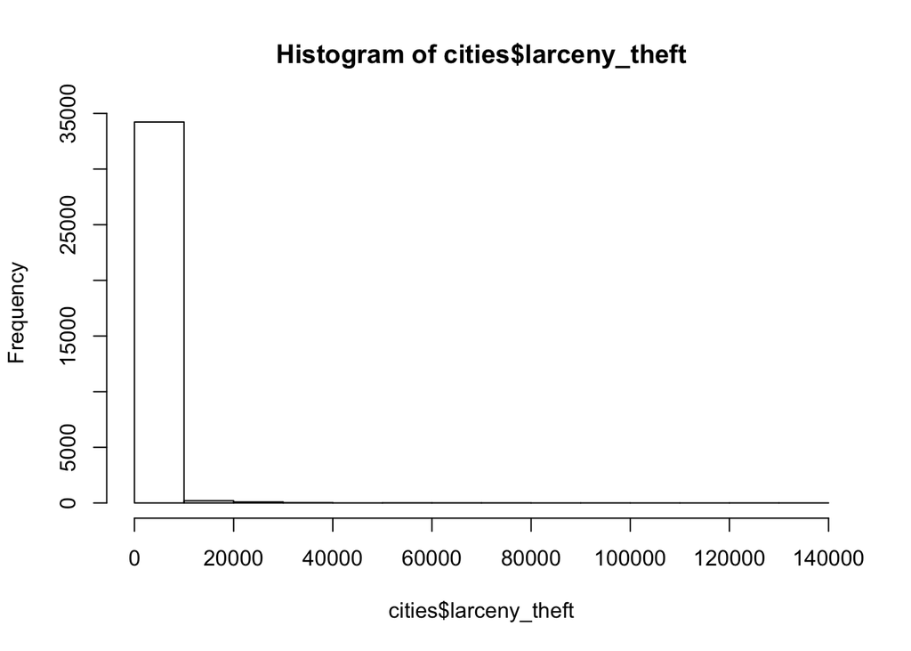

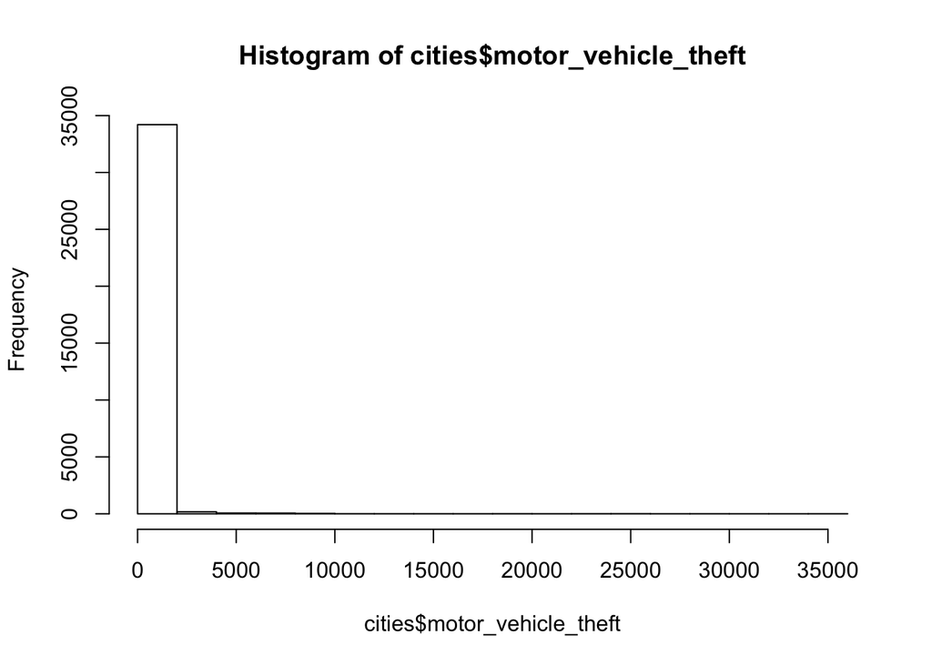

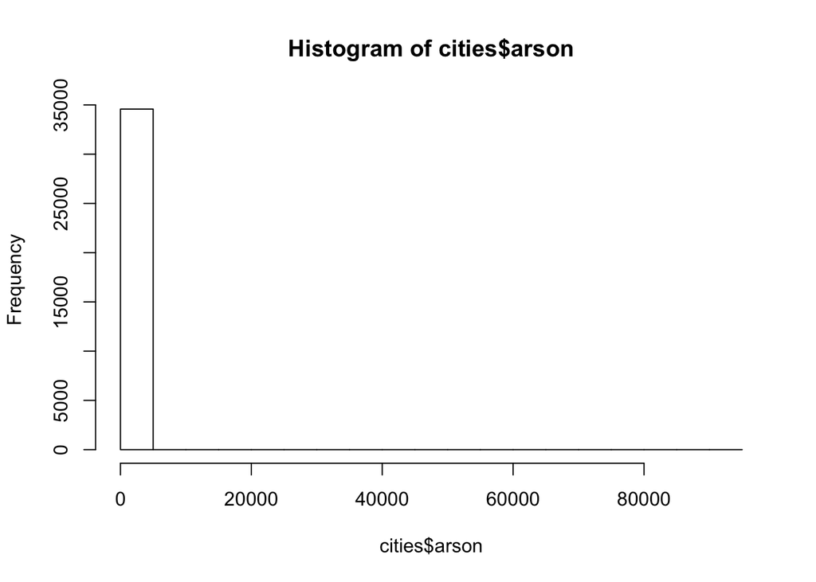

[2 more figures not shown]

# Univariate Analysis by Population

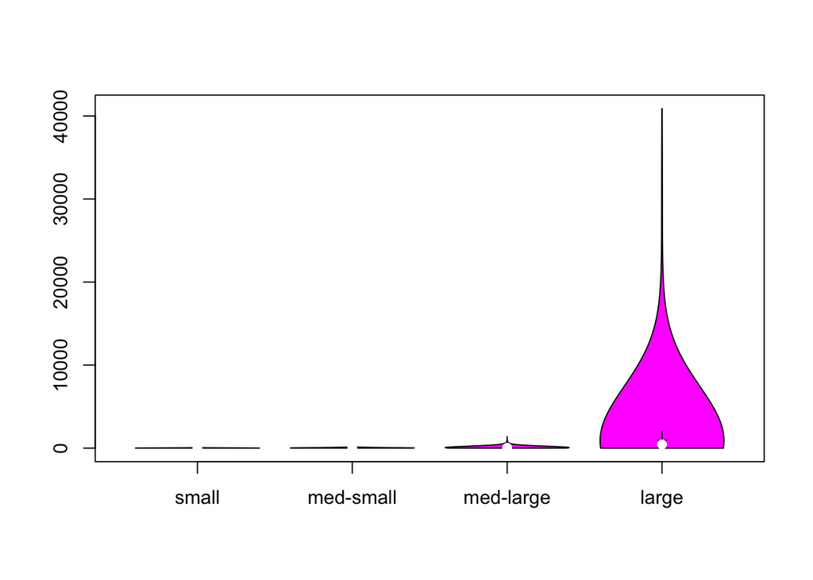

```r
# aggravated assault by population size
vioplot(
  small.pop$aggravated_assault,
  med.small.pop$aggravated_assault,
  med.large.pop$aggravated_assault,
  large.pop$aggravated_assault,
  names=c('small','med-small', 'med-large','large'))
```

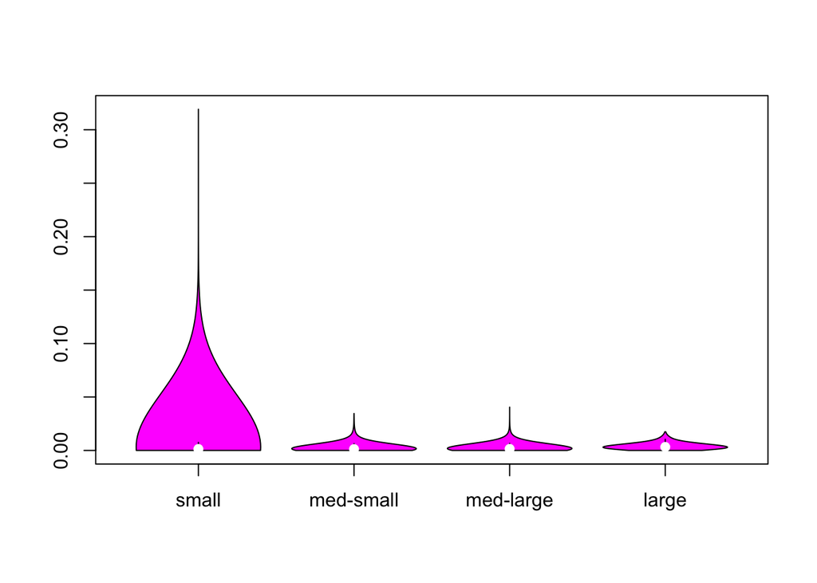

```r
# number of people in a given city per aggravated assault charge
vioplot(
  small.pop$aggravated_assault / small.pop$population,
  med.small.pop$aggravated_assault / med.small.pop$population,
  med.large.pop$aggravated_assault / med.large.pop$population,
  large.pop$aggravated_assault / large.pop$population,
names=c('small','med-small', 'med-large','large'))
```

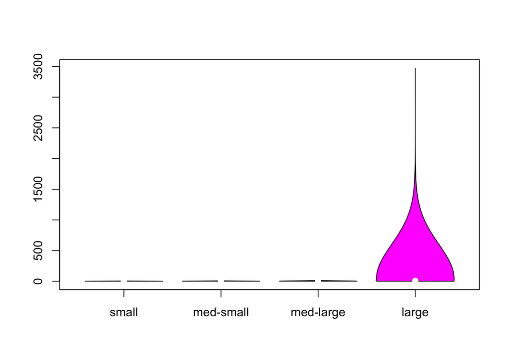

```r
vioplot(
  small.pop$murder_and_non_negligent_man_slaughter,
  med.small.pop$murder_and_non_negligent_man_slaughter,
  med.large.pop$murder_and_non_negligent_man_slaughter,
  large.pop$murder_and_non_negligent_man_slaughter,
  names=c('small','med-small', 'med-large','large'))
```

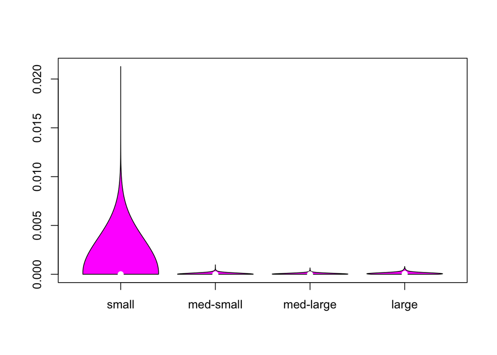

```r
vioplot(
  small.pop$murders_per_person,
  med.small.pop$murders_per_person,
  med.large.pop$murders_per_person,
  large.pop$murders_per_person,
  names=c('small','med-small', 'med-large','large'))
```

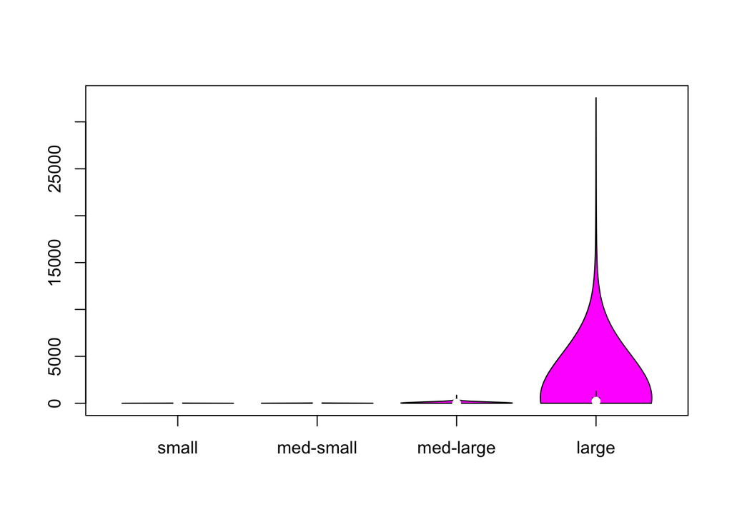

```r
vioplot(
  small.pop$robbery,
  med.small.pop$robbery,
  med.large.pop$robbery,
  large.pop$robbery,
  names=c('small','med-small', 'med-large','large'))
```

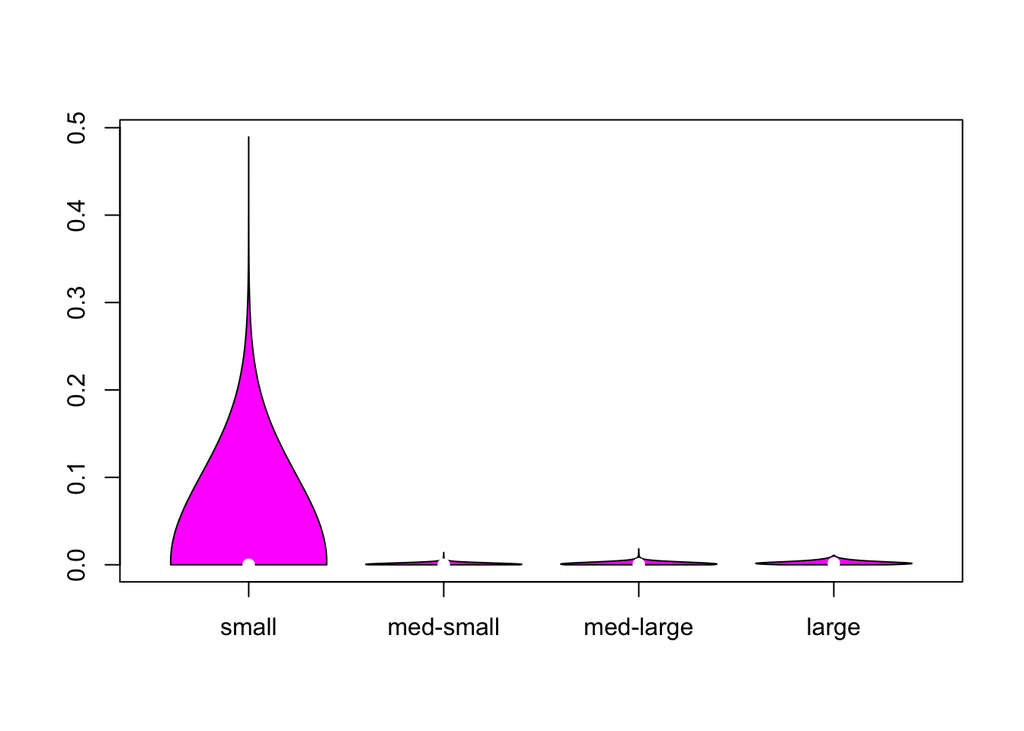

```r
vioplot(
  small.pop$robbery_per_person,
  med.small.pop$robbery_per_person,
  med.large.pop$robbery_per_person,
  large.pop$robbery_per_person,
  names=c('small','med-small', 'med-large','large'))
```

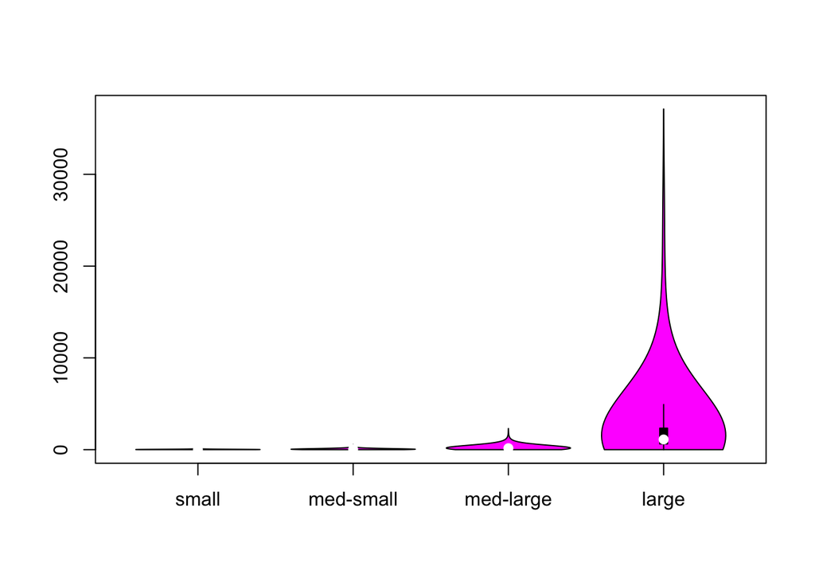

```r
vioplot(
  small.pop$burglary,
  med.small.pop$burglary,
  med.large.pop$burglary,
  large.pop$burglary,
  names=c('small','med-small', 'med-large','large'))
```

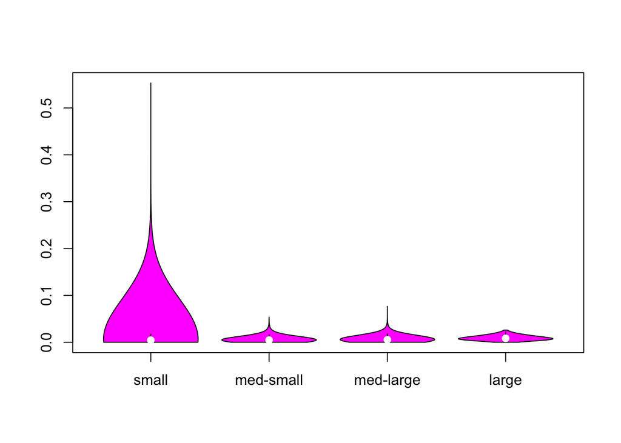

```r
vioplot(
  small.pop$burglary_per_person,
  med.small.pop$burglary_per_person,
  med.large.pop$burglary_per_person,
  large.pop$burglary_per_person,
  names=c('small','med-small', 'med-large','large'))
```

# Univariate Analysis by Year

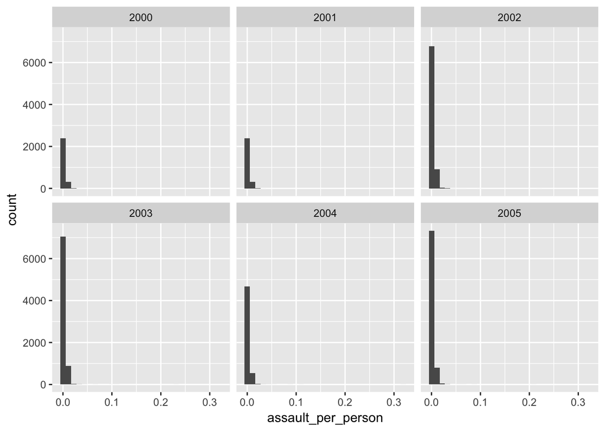

```r
p <- qplot(assault_per_person, data = cities, geom = "histogram")
p + facet_wrap(~ year)
```

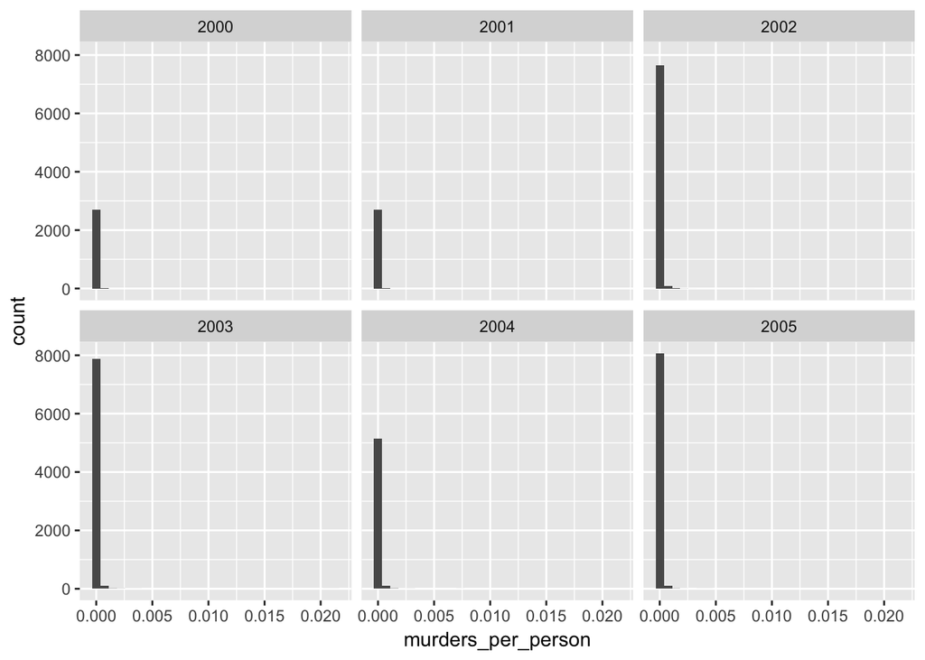

```r
p <- qplot(murders_per_person, data = cities, geom = "histogram")
p + facet_wrap(~ year)
```

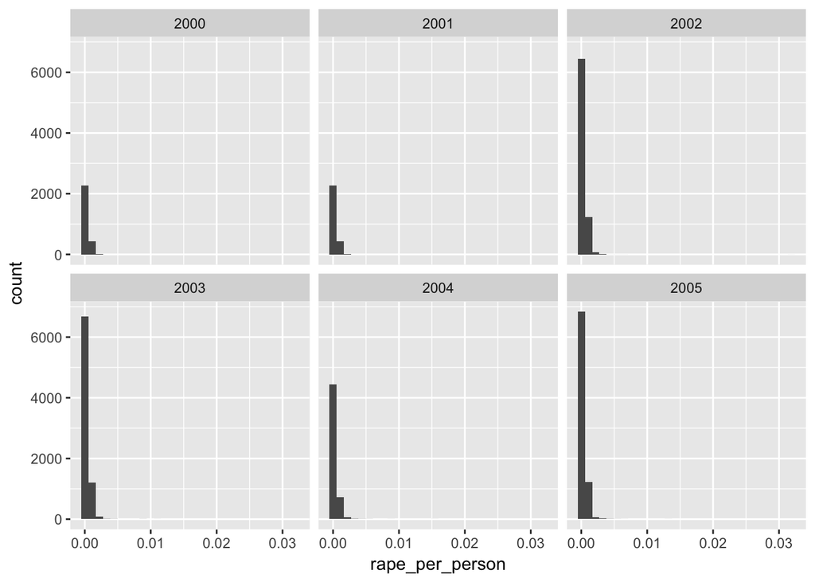

```r
p <- qplot(rape_per_person, data = cities, geom = "histogram")
p + facet_wrap(~ year)
```

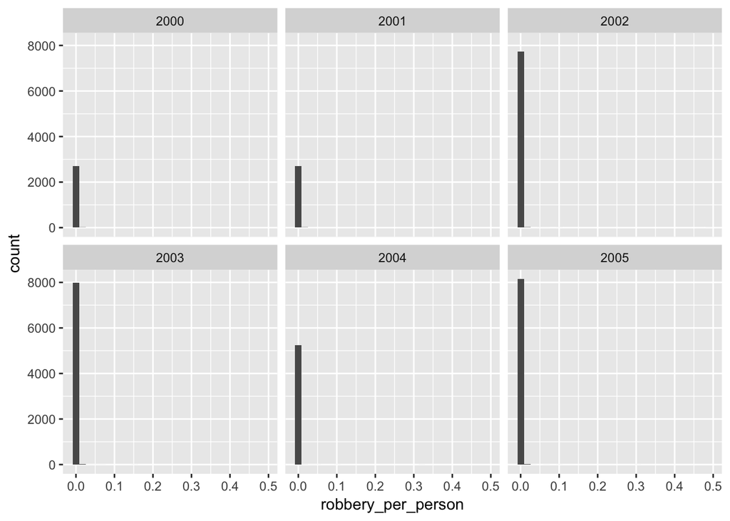

```r
p <- qplot(robbery_per_person, data = cities, geom = "histogram")
p + facet_wrap(~ year)
```

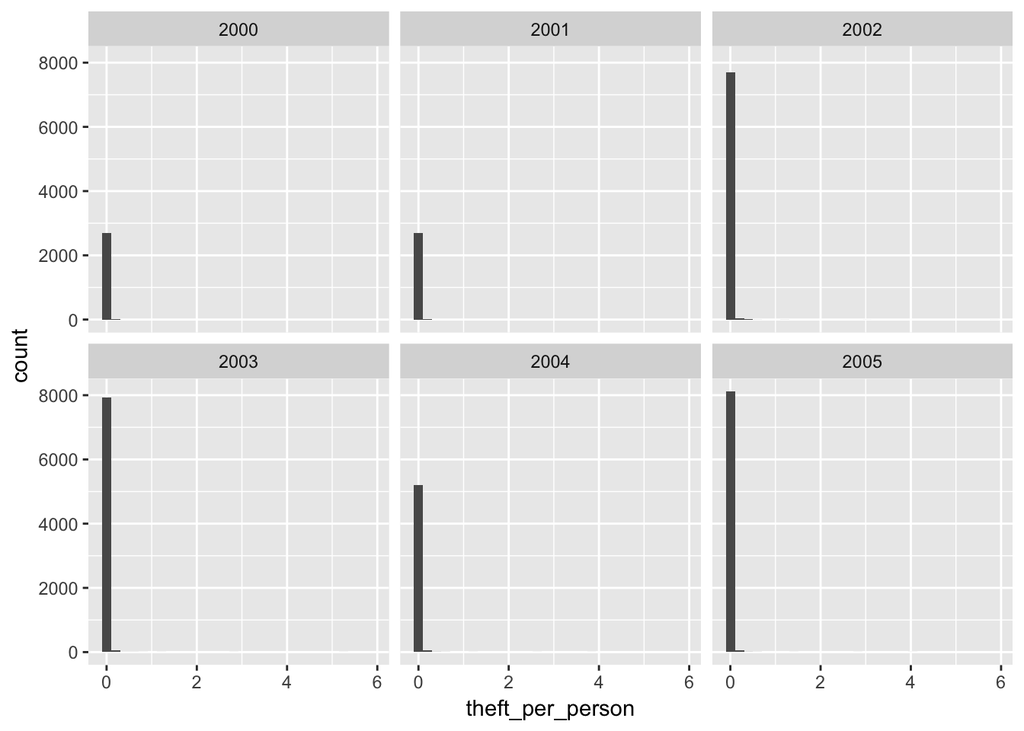

```r
p <- qplot(theft_per_person, data = cities, geom = "histogram")
p + facet_wrap(~ year)
```

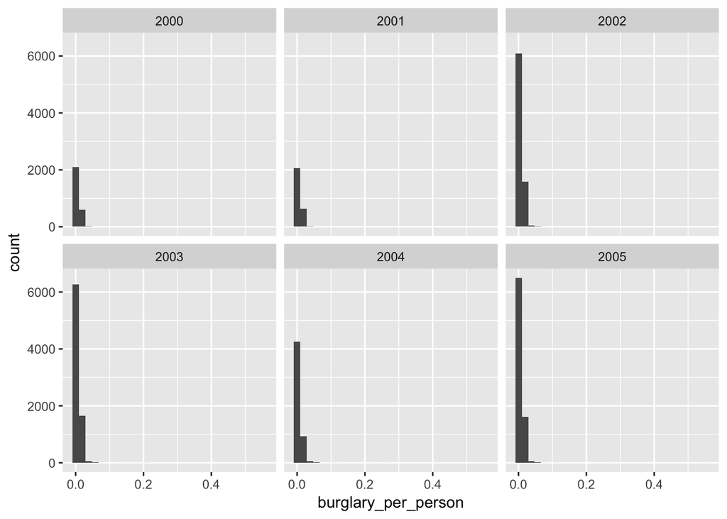

```r
p <- qplot(burglary_per_person, data = cities, geom = "histogram")
p + facet_wrap(~ year)
```

# Bivariate Analysis

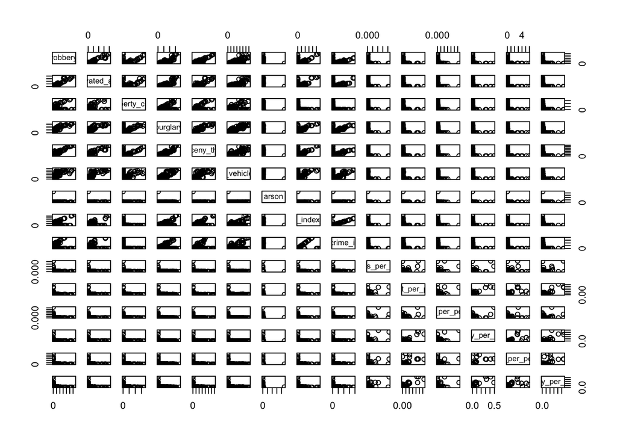

```r
pairs(cities[,8:ncol(cities)])
```

```r
# look at correlation between population to assaults per person
t.test(cities$assault_per_person,cities$population)
```

```
##
##  Welch Two Sample t-test
##
## data:  cities$assault_per_person and cities$population
## t = -31.164, df = 34582, p-value < 2.2e-16
## alternative hypothesis: true difference in means is not equal to 0
## 95 percent confidence interval:
##  -25942.85 -22872.67
## sample estimates:
##    mean of x    mean of y
## 2.489920e-03 2.440776e+04
```

```r
# look at correlation between population to murders per person within cities
t.test(cities$murders_per_person,cities$population)
```

```
##
##  Welch Two Sample t-test
##
## data:  cities$murders_per_person and cities$population
## t = -31.164, df = 34582, p-value < 2.2e-16
## alternative hypothesis: true difference in means is not equal to 0
## 95 percent confidence interval:
##  -25942.85 -22872.67
## sample estimates:
##    mean of x    mean of y
## 3.132784e-05 2.440776e+04
```

```r
# look at correlation between population to theft per person within cities
t.test(cities$theft_per_person,cities$population)
```

```
##
##  Welch Two Sample t-test
##
## data:  cities$theft_per_person and cities$population
## t = -31.164, df = 34582, p-value < 2.2e-16
## alternative hypothesis: true difference in means is not equal to 0
## 95 percent confidence interval:
##  -25942.83 -22872.65
## sample estimates:
##    mean of x    mean of y
## 2.528640e-02 2.440776e+04
```

```r
# look at correlation between population to robbery per person within cities
t.test(cities$robbery_per_person,cities$population)
```

```
##
##  Welch Two Sample t-test
##
## data:  cities$robbery_per_person and cities$population
## t = -31.164, df = 34582, p-value < 2.2e-16
## alternative hypothesis: true difference in means is not equal to 0
## 95 percent confidence interval:
##  -25942.85 -22872.67
## sample estimates:
##    mean of x    mean of y
## 7.336897e-04 2.440776e+04
```

# Summary of Insights

I found some interesting things while exploring the data. One thing that popped out to me was that small towns had much higher rates of crime per person it seemed. I am curious is more crimes go unreported in the cities, or if law enforcement is not able to keep up with all the crime and people are not charged. I was expecting the exact opposite - that larger populations would have higher crime rates.

There are also many points in the data where, as mentioned from the source, there was not any repoting done. For this assignment I set those values to zero so that I could calculate things easier. However it might be more appropriate for the final to remove rows with unreported columns or limit the amount of unreported columns in a given row.

Finally, I think that it might be good to bring in some other data to make this analysis more interesting. Possibley education data from these cities or economic data. On its own I am not sure population can speak for all of the crime data we see here. So there are plenty of things to explore moving forward.